# Project_1_DS_6372

Jake

2023-09-17

```r
library(caret)
library(corrplot)
library(GGally)
```

# MSDS 6372 Project 1

## Goal

We would like to predict medical costs for insurance claims.

## EDA

### Things we need to do

- Deal with missing data if there is any
- Clean up variable names
- change data types
- split data into train/validation split first (then use training data for objectives)

### EDA needs to include

- discussion of trends between the response and predictors

```r
# Set seed for reproducability
set.seed(1234)

# Read in data
raw_data <- read.csv("../raw_data/insurance.csv")
summary(raw_data)
```

```
##       age            sex                 bmi           children
##  Min.   :18.00   Length:1338        Min.   :15.96   Min.   :0.000
##  1st Qu.:27.00   Class :character   1st Qu.:26.30   1st Qu.:0.000
##  Median :39.00   Mode  :character   Median :30.40   Median :1.000
##  Mean   :39.21                      Mean   :30.66   Mean   :1.095
##  3rd Qu.:51.00                      3rd Qu.:34.69   3rd Qu.:2.000
##  Max.   :64.00                      Max.   :53.13   Max.   :5.000
##     smoker             region             charges
##  Length:1338        Length:1338        Min.   : 1122
##  Class :character   Class :character   1st Qu.: 4740
##  Mode  :character   Mode  :character   Median : 9382
##                                        Mean   :13270
##                                        3rd Qu.:16640
##                                        Max.   :63770
```

```r
# Change data types
clean_data <- raw_data
factor_varibales <- c("sex", "smoker", "region")

for (var in factor_varibales) {
  clean_data[[var]] <- as.factor(clean_data[[var]])
}

# Define the proportion for the training set
split_perecnt = 0.7
train_index <- sample(1:nrow(clean_data), nrow(clean_data) * split_perecnt)

train_data <- clean_data[train_index, ]
validation_data <- clean_data[-train_index, ]

# Display the first few rows of the dataset
head(train_data)
```

```
##      age    sex   bmi children smoker    region   charges
## 1308  32   male 28.12        4    yes northwest 21472.479
## 1018  26 female 34.20        2     no southwest  3987.926
## 1125  23 female 42.75        1    yes northeast 40904.200
## 1004  48   male 29.60        0     no southwest 21232.182
## 623   49 female 21.30        1     no southwest  9182.170
## 905   60 female 35.10        0     no southwest 12644.589
```

```r
# Display the structure of the dataset
str(train_data)
```

```
## 'data.frame':    936 obs. of  7 variables:
##  $ age     : int  32 26 23 48 49 60 43 45 18 19 ...
##  $ sex     : Factor w/ 2 levels "female","male": 2 1 1 2 1 1 2 1 1 1 ...
##  $ bmi     : num  28.1 34.2 42.8 29.6 21.3 ...
##  $ children: int  4 2 1 0 1 0 2 0 0 0 ...
##  $ smoker  : Factor w/ 2 levels "no","yes": 2 1 2 1 1 1 1 1 1 1 ...
##  $ region  : Factor w/ 4 levels "northeast","northwest",..: 2 4 1 4 4 4 3 4 3 2 ...
##  $ charges : num  21472 3988 40904 21232 9182 ...
```

```r
# Summary statistics for each column
summary(train_data)
```

```
##       age            sex           bmi           children     smoker
##  Min.   :18.00   female:467   Min.   :16.82   Min.   :0.000   no :743
##  1st Qu.:26.00   male  :469   1st Qu.:26.11   1st Qu.:0.000   yes:193
##  Median :39.00                Median :30.20   Median :1.000
##  Mean   :39.29                Mean   :30.70   Mean   :1.043
##  3rd Qu.:51.00                3rd Qu.:34.99   3rd Qu.:2.000
##  Max.   :64.00                Max.   :53.13   Max.   :5.000
##        region       charges
##  northeast:234   Min.   : 1132
##  northwest:213   1st Qu.: 4710
##  southeast:266   Median : 9630
##  southwest:223   Mean   :13554
##                  3rd Qu.:17141
##                  Max.   :63770
```

```r
# Count missing values in each column
sapply(train_data, function(x) sum(is.na(x)))
```

```
##      age      sex      bmi children   smoker   region  charges
##        0        0        0        0        0        0        0
```

```r
correlation_matrix <- cor(train_data[, sapply(train_data, is.numeric)], use="pairwise.complete.obs")
print(correlation_matrix)
```

```
##                 age         bmi    children    charges
## age      1.00000000  0.10032212  0.06529928 0.27885671
## bmi      0.10032212  1.00000000 -0.01727691 0.21550917
## children 0.06529928 -0.01727691  1.00000000 0.07040377
## charges  0.27885671  0.21550917  0.07040377 1.00000000
```

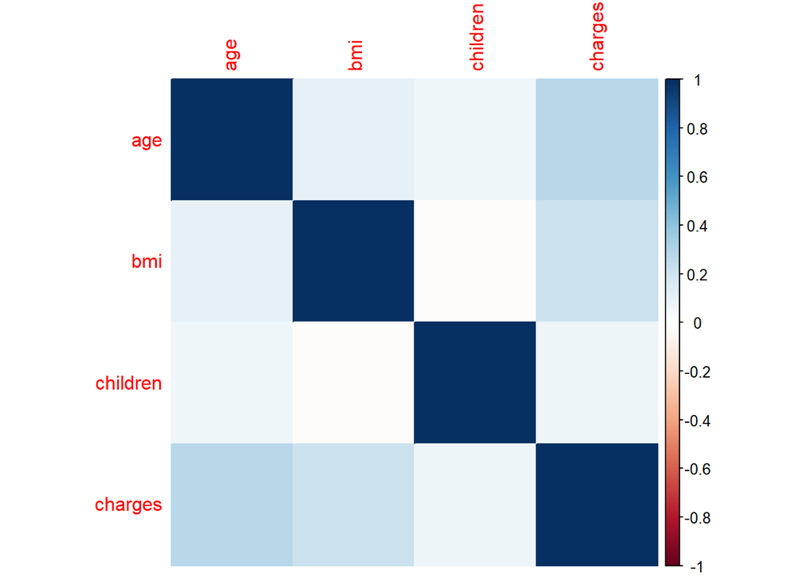

```r
# Visualize the correlation matrix using a heat map
corrplot(correlation_matrix, method="color")
```

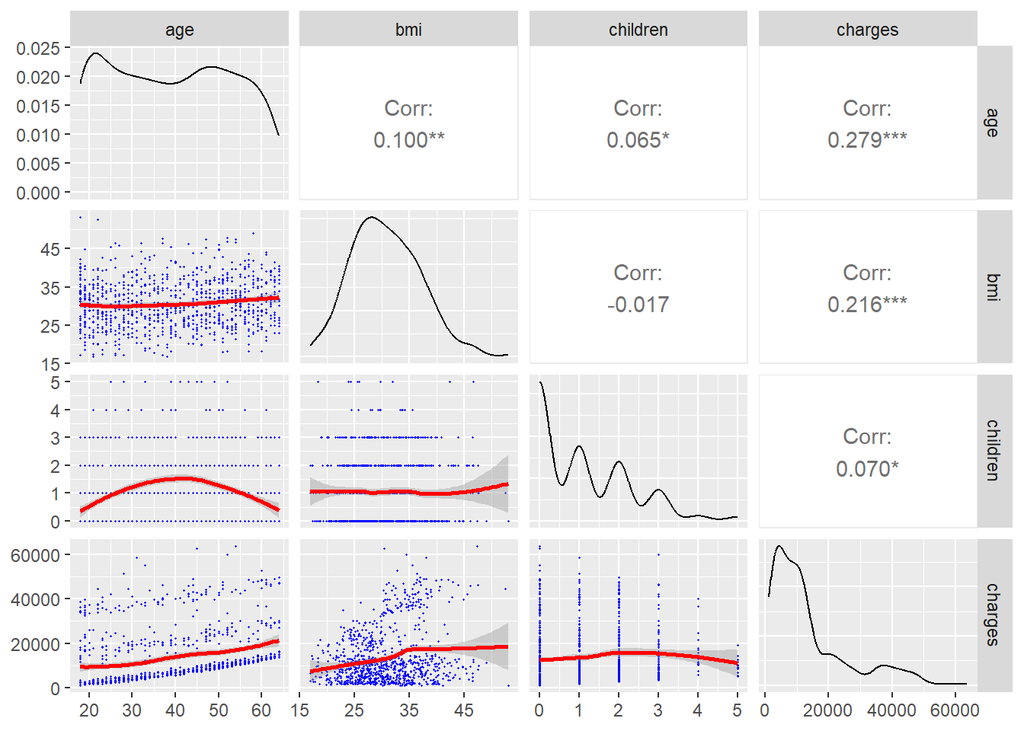

```r
#Getting fancy
lowerFn <- function(data, mapping, method = "lm", ...) {
  p <- ggplot(data = data, mapping = mapping) +
    geom_point(colour = "blue",size=.2) +
    geom_smooth(method = loess, color = "red", ...)
  p
}


ggpairs(train_data[, sapply(train_data, is.numeric)],lower=list(continuous=lowerFn),progress = F)
```

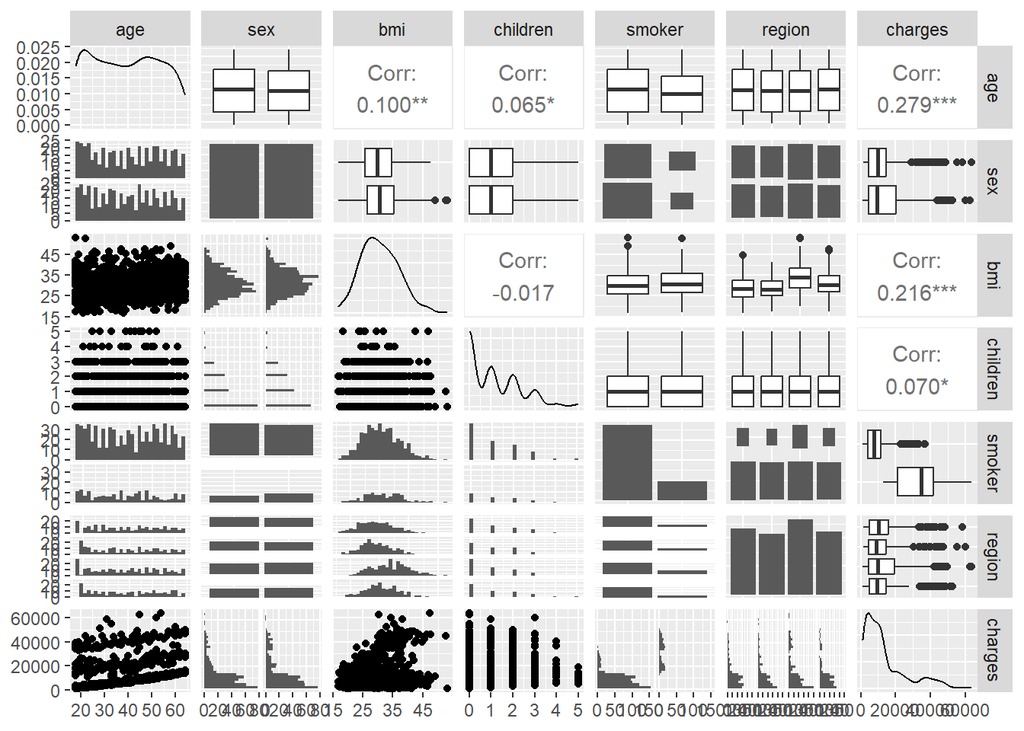

```r
ggpairs(train_data)
```

## Objective 1

We need to create a interpretable model

- Build a model with the main goal to identify key relationships that is highly interpret able.
- Provide interpretation of the regression coefficients
  - Include hypotheses testing
  - Interpretation of regression coefficients
  - Confidence intervals
  - Mention the practical vs statistical significance of the predictors
- Interpretation of at least a subset of the predictors in your final model
  - Tests on coefficients
  - assumption checking interpreting those coefficients
- Feature selection

## Objective 2

Develop a model that can predict the best and do well on future data

- Train/validation or CV approach for model comparisons
- Create a linear regression model WITH complexity (not just include a model with predictors that you’ve eliminated from objective 1)
- Run one non-parametric model to compare to your complex model
- Provide measures of fit for comparisons
  - MSE
  - R squared / Ajusted R squared
  - AIC & BIC
- Use validation set to show results DO NOT tune model based on validation set
- Feature selection and CV are a must here